# PracticalMachineLearningProjectMI

Matthias Ihl

13/9/2018

## Summary

In this project, we study data coming from accelerometers on the belt, forearm, arm, and dumbell of 6 research participants. The training data includes the accelerometer data and a label describing the quality of the exercise the participants were executing. The test data misses the quality label and the goal of this project is to predict this label in the test set. I will describe step by step how to build the model, estimate the out-of sample error and make prediction.

## Preparation of the data

First, let us load the caret and other packets and read the data:

```r
library(caret)
library(rpart)
library(rattle)
library(randomForest)
training <- read.csv("~/Desktop/Coursera/pml-training.csv")
testing <- read.csv("~/Desktop/Coursera/pml-testing.csv")
```

In order to estimate out-of-sample error, let us further split the training set into a training and validation set:

```r
set.seed(23456)
inTrain <- createDataPartition(y=training$classe, p=0.75, list=FALSE)
training_train <- training[inTrain, ]
training_valid <- training[-inTrain, ]
```

I will now apply a method I learned recently, namely removing variables with “near zero variance” which turn out to be generally not useful for predicting outcomes. Moreover, all irrelevant variables and those that are mostly NA will be eliminated as well.

```r
# irrelevant variables
training_train <- training_train[, -(1:5)]
training_valid <- training_valid[, -(1:5)]
# mostly NA (in training set)
mostlyNA <- sapply(training_train, function(x) mean(is.na(x))) > 0.8
training_train <- training_train[, mostlyNA==FALSE]
training_valid <- training_valid[, mostlyNA==FALSE]
# near zero variance
NZV <- nearZeroVar(training_train)
training_train <- training_train[, -NZV]
training_valid <- training_valid[, -NZV]
summary(training_train)
```

```
##    num_window      roll_belt        pitch_belt          yaw_belt
##  Min.   :  1.0   Min.   :-28.90   Min.   :-55.8000   Min.   :-180.00
##  1st Qu.:222.2   1st Qu.:  1.09   1st Qu.:  1.8325   1st Qu.: -88.30
##  Median :424.0   Median :113.00   Median :  5.2900   Median : -14.40
##  Mean   :431.0   Mean   : 64.04   Mean   :  0.3925   Mean   : -11.83
##  3rd Qu.:644.0   3rd Qu.:123.00   3rd Qu.: 14.8000   3rd Qu.:  12.05
##  Max.   :864.0   Max.   :162.00   Max.   : 60.3000   Max.   : 179.00
##  total_accel_belt  gyros_belt_x        gyros_belt_y       gyros_belt_z
##  Min.   : 0.00    Min.   :-1.000000   Min.   :-0.64000   Min.   :-1.4600
##  1st Qu.: 3.00    1st Qu.:-0.030000   1st Qu.: 0.00000   1st Qu.:-0.2000
##  Median :17.00    Median : 0.030000   Median : 0.02000   Median :-0.1000
##  Mean   :11.28    Mean   :-0.005601   Mean   : 0.03884   Mean   :-0.1306
##  3rd Qu.:18.00    3rd Qu.: 0.110000   3rd Qu.: 0.11000   3rd Qu.:-0.0200
##  Max.   :29.00    Max.   : 2.220000   Max.   : 0.63000   Max.   : 1.6200
##   accel_belt_x       accel_belt_y     accel_belt_z     magnet_belt_x
##  Min.   :-120.000   Min.   :-65.00   Min.   :-275.00   Min.   :-52.00
##  1st Qu.: -21.000   1st Qu.:  3.00   1st Qu.:-162.00   1st Qu.:  9.00
##  Median : -15.000   Median : 32.00   Median :-151.00   Median : 34.00
##  Mean   :  -5.697   Mean   : 29.98   Mean   : -72.01   Mean   : 55.25
##  3rd Qu.:  -5.000   3rd Qu.: 61.00   3rd Qu.:  28.00   3rd Qu.: 59.00
##  Max.   :  83.000   Max.   :164.00   Max.   : 104.00   Max.   :485.00
##  magnet_belt_y   magnet_belt_z       roll_arm         pitch_arm
##  Min.   :359.0   Min.   :-623.0   Min.   :-180.00   Min.   :-88.800
##  1st Qu.:581.0   1st Qu.:-375.0   1st Qu.: -31.57   1st Qu.:-25.900
##  Median :601.0   Median :-319.0   Median :   0.00   Median :  0.000
##  Mean   :593.7   Mean   :-345.4   Mean   :  17.56   Mean   : -4.676
##  3rd Qu.:610.0   3rd Qu.:-306.0   3rd Qu.:  77.00   3rd Qu.: 11.100
##  Max.   :673.0   Max.   : 293.0   Max.   : 180.00   Max.   : 88.500
##     yaw_arm          total_accel_arm  gyros_arm_x        gyros_arm_y
##  Min.   :-180.0000   Min.   : 1.00   Min.   :-6.37000   Min.   :-3.4400
##  1st Qu.: -42.5000   1st Qu.:17.00   1st Qu.:-1.33000   1st Qu.:-0.7900
##  Median :   0.0000   Median :27.00   Median : 0.06000   Median :-0.2400
##  Mean   :  -0.3046   Mean   :25.49   Mean   : 0.03511   Mean   :-0.2564
##  3rd Qu.:  46.3000   3rd Qu.:33.00   3rd Qu.: 1.56000   3rd Qu.: 0.1600
##  Max.   : 180.0000   Max.   :65.00   Max.   : 4.87000   Max.   : 2.8400
##   gyros_arm_z       accel_arm_x       accel_arm_y       accel_arm_z
##  Min.   :-2.1700   Min.   :-404.00   Min.   :-318.00   Min.   :-613.00
##  1st Qu.:-0.0800   1st Qu.:-241.00   1st Qu.: -54.00   1st Qu.:-144.00
##  Median : 0.2300   Median : -43.00   Median :  15.00   Median : -47.00
##  Mean   : 0.2637   Mean   : -59.92   Mean   :  33.23   Mean   : -71.22
```

[output cut: 43 more lines]

```
##  Max.   :79.00       Max.   : 3.4800   Max.   : 6.13000
##  gyros_forearm_z   accel_forearm_x   accel_forearm_y  accel_forearm_z
##  Min.   :-7.9400   Min.   :-498.00   Min.   :-632.0   Min.   :-446.00
##  1st Qu.:-0.1800   1st Qu.:-178.00   1st Qu.:  60.0   1st Qu.:-182.00
##  Median : 0.0800   Median : -56.00   Median : 201.5   Median : -43.00
##  Mean   : 0.1403   Mean   : -61.13   Mean   : 164.5   Mean   : -56.16
##  3rd Qu.: 0.4900   3rd Qu.:  77.00   3rd Qu.: 312.0   3rd Qu.:  26.00
##  Max.   : 4.1000   Max.   : 389.00   Max.   : 591.0   Max.   : 291.00
##  magnet_forearm_x  magnet_forearm_y magnet_forearm_z classe
##  Min.   :-1280.0   Min.   :-896.0   Min.   :-973.0   A:4185
##  1st Qu.: -616.8   1st Qu.:   9.0   1st Qu.: 194.0   B:2848
##  Median : -379.0   Median : 592.0   Median : 512.0   C:2567
##  Mean   : -313.3   Mean   : 381.6   Mean   : 396.1   D:2412
##  3rd Qu.:  -75.0   3rd Qu.: 736.0   3rd Qu.: 654.0   E:2706
##  Max.   :  672.0   Max.   :1480.0   Max.   :1090.0
```

```r
summary(training_valid)
```

```
##    num_window      roll_belt        pitch_belt          yaw_belt
##  Min.   :  1.0   Min.   :-28.60   Min.   :-54.9000   Min.   :-179.000
##  1st Qu.:220.0   1st Qu.:  1.14   1st Qu.:  1.5175   1st Qu.: -88.200
##  Median :422.0   Median :115.00   Median :  5.2700   Median :  -8.960
##  Mean   :429.7   Mean   : 65.50   Mean   :  0.0434   Mean   :  -9.339
##  3rd Qu.:645.0   3rd Qu.:123.00   3rd Qu.: 15.5000   3rd Qu.:  14.925
##  Max.   :864.0   Max.   :161.00   Max.   : 60.1000   Max.   : 179.000
##  total_accel_belt  gyros_belt_x        gyros_belt_y       gyros_belt_z
##  Min.   : 0.0     Min.   :-1.040000   Min.   :-0.45000   Min.   :-1.3300
##  1st Qu.: 3.0     1st Qu.:-0.050000   1st Qu.: 0.00000   1st Qu.:-0.2000
##  Median :17.0     Median : 0.030000   Median : 0.02000   Median :-0.1100
##  Mean   :11.4     Mean   :-0.005567   Mean   : 0.04183   Mean   :-0.1302
##  3rd Qu.:18.0     3rd Qu.: 0.110000   3rd Qu.: 0.11000   3rd Qu.:-0.0200
##  Max.   :28.0     Max.   : 2.020000   Max.   : 0.64000   Max.   : 1.6100
##   accel_belt_x      accel_belt_y     accel_belt_z     magnet_belt_x
##  Min.   :-81.000   Min.   :-69.00   Min.   :-266.00   Min.   :-49.00
##  1st Qu.:-21.000   1st Qu.:  3.00   1st Qu.:-162.00   1st Qu.: 10.00
##  Median :-15.000   Median : 40.00   Median :-154.00   Median : 35.00
##  Mean   : -5.288   Mean   : 30.68   Mean   : -74.35   Mean   : 56.64
##  3rd Qu.: -4.000   3rd Qu.: 61.00   3rd Qu.:  27.00   3rd Qu.: 61.00
##  Max.   : 85.000   Max.   :150.00   Max.   : 105.00   Max.   :481.00
##  magnet_belt_y   magnet_belt_z       roll_arm         pitch_arm
##  Min.   :354.0   Min.   :-618.0   Min.   :-180.00   Min.   :-88.20
##  1st Qu.:581.0   1st Qu.:-376.0   1st Qu.: -32.12   1st Qu.:-25.80
##  Median :601.0   Median :-320.0   Median :   0.00   Median :  0.00
##  Mean   :593.5   Mean   :-345.8   Mean   :  18.66   Mean   : -4.42
##  3rd Qu.:610.0   3rd Qu.:-306.0   3rd Qu.:  78.30   3rd Qu.: 11.90
##  Max.   :667.0   Max.   : 289.0   Max.   : 180.00   Max.   : 87.10
##     yaw_arm         total_accel_arm  gyros_arm_x        gyros_arm_y
##  Min.   :-180.000   Min.   : 1.00   Min.   :-6.36000   Min.   :-3.3200
##  1st Qu.: -44.225   1st Qu.:17.00   1st Qu.:-1.30000   1st Qu.:-0.8000
##  Median :   0.000   Median :27.00   Median : 0.11000   Median :-0.2700
##  Mean   :  -1.562   Mean   :25.57   Mean   : 0.06577   Mean   :-0.2592
##  3rd Qu.:  44.800   3rd Qu.:33.00   3rd Qu.: 1.59000   3rd Qu.: 0.1300
##  Max.   : 180.000   Max.   :66.00   Max.   : 4.87000   Max.   : 2.8100
##   gyros_arm_z      accel_arm_x       accel_arm_y       accel_arm_z
##  Min.   :-2.330   Min.   :-341.00   Min.   :-302.00   Min.   :-636.00
##  1st Qu.:-0.050   1st Qu.:-243.00   1st Qu.: -55.00   1st Qu.:-141.00
##  Median : 0.260   Median : -46.00   Median :  10.50   Median : -47.00
##  Mean   : 0.287   Mean   : -61.21   Mean   :  30.71   Mean   : -71.33
```

[output cut: 50 more lines]

```
##  Max.   :311.0000   Max.   :231.0000   Max.   : 477.00   Max.   : 923.0
##  accel_forearm_z   magnet_forearm_x  magnet_forearm_y magnet_forearm_z
##  Min.   :-410.00   Min.   :-1280.0   Min.   :-890.0   Min.   :-966.0
##  1st Qu.:-182.00   1st Qu.: -613.2   1st Qu.: -19.0   1st Qu.: 172.0
##  Median : -34.00   Median : -375.0   Median : 589.0   Median : 506.0
##  Mean   : -52.69   Mean   : -310.3   Mean   : 375.7   Mean   : 386.1
##  3rd Qu.:  26.00   3rd Qu.:  -72.0   3rd Qu.: 739.0   3rd Qu.: 650.0
##  Max.   : 254.00   Max.   :  661.0   Max.   :1450.0   Max.   :1080.0
##  classe
##  A:1395
##  B: 949
##  C: 855
##  D: 804
##  E: 901
##
```

## Building the model

The first attempt will be to model the data with descision trees:

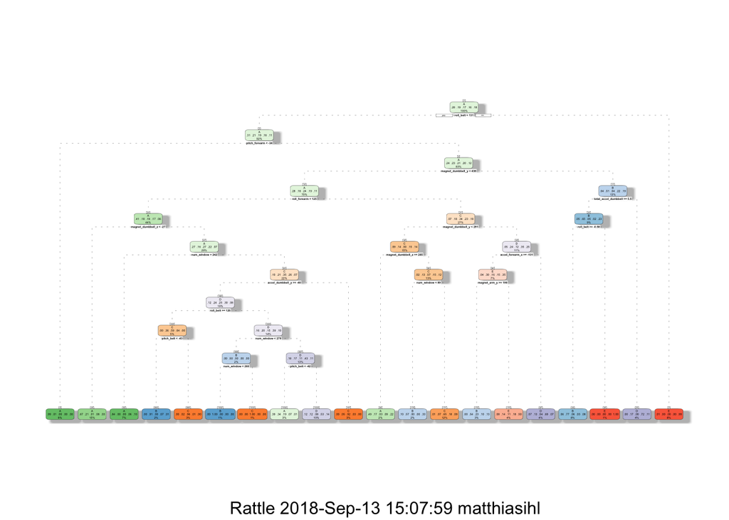

```r
set.seed(23456)
modelFit_dt <- rpart(classe ~ ., data=training_train, method="class")
fancyRpartPlot(modelFit_dt)
```

Let’s predict the classe variable in the validation set:

```r
predict_dt <- predict(modelFit_dt, training_valid, type = "class")
cm_dt <- confusionMatrix(predict_dt, training_valid$classe)
cm_dt
```

```
## Confusion Matrix and Statistics
##
##           Reference
## Prediction    A    B    C    D    E
##          A 1254  214   45  107   84
##          B   33  542   63   29   90
##          C    9   47  680  110   54
##          D   80  112   44  522  112
##          E   19   34   23   36  561
##
## Overall Statistics
##
##                Accuracy : 0.7257
##                  95% CI : (0.713, 0.7382)
##     No Information Rate : 0.2845
##     P-Value [Acc > NIR] : < 2.2e-16
##
##                   Kappa : 0.6506
##  Mcnemar's Test P-Value : < 2.2e-16
##
## Statistics by Class:
##
##                      Class: A Class: B Class: C Class: D Class: E
## Sensitivity            0.8989   0.5711   0.7953   0.6493   0.6226
## Specificity            0.8718   0.9456   0.9457   0.9151   0.9720
## Pos Pred Value         0.7359   0.7160   0.7556   0.6000   0.8336
## Neg Pred Value         0.9559   0.9019   0.9563   0.9301   0.9196
## Prevalence             0.2845   0.1935   0.1743   0.1639   0.1837
## Detection Rate         0.2557   0.1105   0.1387   0.1064   0.1144
## Detection Prevalence   0.3475   0.1544   0.1835   0.1774   0.1372
## Balanced Accuracy      0.8853   0.7584   0.8705   0.7822   0.7973
```

Next, we will try to predict with random forests:

```r
set.seed(23456)
modelFit_rf <- randomForest(classe ~ ., data=training_train)
predict_rf <- predict(modelFit_rf, training_valid, type = "class")
cm_rf <- confusionMatrix(predict_rf, training_valid$classe)
cm_rf
```

```
## Confusion Matrix and Statistics
##
##           Reference
## Prediction    A    B    C    D    E
##          A 1395    2    0    0    0
##          B    0  946    6    0    0
##          C    0    1  849    4    0
##          D    0    0    0  800    3
##          E    0    0    0    0  898
##
## Overall Statistics
##
##                Accuracy : 0.9967
##                  95% CI : (0.9947, 0.9981)
##     No Information Rate : 0.2845
##     P-Value [Acc > NIR] : < 2.2e-16
##
##                   Kappa : 0.9959
##  Mcnemar's Test P-Value : NA
##
## Statistics by Class:
##
##                      Class: A Class: B Class: C Class: D Class: E
## Sensitivity            1.0000   0.9968   0.9930   0.9950   0.9967
## Specificity            0.9994   0.9985   0.9988   0.9993   1.0000
## Pos Pred Value         0.9986   0.9937   0.9941   0.9963   1.0000
## Neg Pred Value         1.0000   0.9992   0.9985   0.9990   0.9993
## Prevalence             0.2845   0.1935   0.1743   0.1639   0.1837
## Detection Rate         0.2845   0.1929   0.1731   0.1631   0.1831
## Detection Prevalence   0.2849   0.1941   0.1741   0.1637   0.1831
## Balanced Accuracy      0.9997   0.9977   0.9959   0.9971   0.9983
```

Lastly, let us try boosting: Unfortunately, it took too long to evaluate this on my old laptop! Therefore, in light of the very high accuracy of random forests, I assume that random forests are the best method and will use that method below.

```r
set.seed(23456)
ModelFit_gbm <- train(classe ~ ., data=training_train, method = "gbm", verbose = FALSE)

predict_gbm <- predict(ModelFit_gbm$finalModel, newdata=training_valid)
cm_gbm <- confusionMatrix(predict_gbm, training_valid$classe)
cm_gbm
```

[output not shown]

## Prediction of the test results

```r
predict_test <- predict(modelFit_rf, testing, type = "class")
predict_test
```

```
##  1  2  3  4  5  6  7  8  9 10 11 12 13 14 15 16 17 18 19 20
##  B  A  B  A  A  E  D  B  A  A  B  C  B  A  E  E  A  B  B  B
## Levels: A B C D E
```